# Risk Factor Analysis

## Outcome Variable

**Outcome Variable:** stunted

## Predictor Variables

**Intervention Variable:** birthlen

**Adjustment Set:**

unadjusted

## Stratifying Variables

The analysis was stratified on these variable(s):

- agecat
- studyid
- country

## Data Summary

| agecat | studyid | country | birthlen | stunted | n_cell | n |
| --- | --- | --- | --- | --- | --- | --- |
| Birth | CMC-V-BCS-2002 | INDIA | >=50 cm | 0 | 14 | 92 |
| Birth | CMC-V-BCS-2002 | INDIA | >=50 cm | 1 | 0 | 92 |
| Birth | CMC-V-BCS-2002 | INDIA | <48 cm | 0 | 21 | 92 |
| Birth | CMC-V-BCS-2002 | INDIA | <48 cm | 1 | 17 | 92 |
| Birth | CMC-V-BCS-2002 | INDIA | [48-50) cm | 0 | 40 | 92 |
| Birth | CMC-V-BCS-2002 | INDIA | [48-50) cm | 1 | 0 | 92 |
| Birth | CMIN | BANGLADESH | >=50 cm | 0 | 2 | 26 |
| Birth | CMIN | BANGLADESH | >=50 cm | 1 | 0 | 26 |
| Birth | CMIN | BANGLADESH | <48 cm | 0 | 7 | 26 |
| Birth | CMIN | BANGLADESH | <48 cm | 1 | 9 | 26 |
| Birth | CMIN | BANGLADESH | [48-50) cm | 0 | 8 | 26 |
| Birth | CMIN | BANGLADESH | [48-50) cm | 1 | 0 | 26 |
| Birth | COHORTS | GUATEMALA | >=50 cm | 0 | 437 | 852 |
| Birth | COHORTS | GUATEMALA | >=50 cm | 1 | 0 | 852 |
| Birth | COHORTS | GUATEMALA | <48 cm | 0 | 113 | 852 |
| Birth | COHORTS | GUATEMALA | <48 cm | 1 | 50 | 852 |
| Birth | COHORTS | GUATEMALA | [48-50) cm | 0 | 252 | 852 |
| Birth | COHORTS | GUATEMALA | [48-50) cm | 1 | 0 | 852 |
| Birth | COHORTS | INDIA | >=50 cm | 0 | 1426 | 6640 |
| Birth | COHORTS | INDIA | >=50 cm | 1 | 0 | 6640 |
| Birth | COHORTS | INDIA | <48 cm | 0 | 1982 | 6640 |
| Birth | COHORTS | INDIA | <48 cm | 1 | 792 | 6640 |
| Birth | COHORTS | INDIA | [48-50) cm | 0 | 2440 | 6640 |
| Birth | COHORTS | INDIA | [48-50) cm | 1 | 0 | 6640 |
| Birth | COHORTS | PHILIPPINES | >=50 cm | 0 | 1129 | 3050 |
| Birth | COHORTS | PHILIPPINES | >=50 cm | 1 | 0 | 3050 |
| Birth | COHORTS | PHILIPPINES | <48 cm | 0 | 575 | 3050 |
| Birth | COHORTS | PHILIPPINES | <48 cm | 1 | 187 | 3050 |
| Birth | COHORTS | PHILIPPINES | [48-50) cm | 0 | 1159 | 3050 |
| Birth | COHORTS | PHILIPPINES | [48-50) cm | 1 | 0 | 3050 |

[output cut: 390 more lines]

The following strata were considered:

- agecat: 24 months, studyid: CMC-V-BCS-2002, country: INDIA
- agecat: 24 months, studyid: CMIN, country: BANGLADESH
- agecat: 24 months, studyid: COHORTS, country: GUATEMALA
- agecat: 24 months, studyid: COHORTS, country: INDIA
- agecat: 24 months, studyid: COHORTS, country: PHILIPPINES
- agecat: 24 months, studyid: CONTENT, country: PERU
- agecat: 24 months, studyid: EE, country: PAKISTAN
- agecat: 24 months, studyid: GMS-Nepal, country: NEPAL
- agecat: 24 months, studyid: IRC, country: INDIA
- agecat: 24 months, studyid: Keneba, country: GAMBIA
- agecat: 24 months, studyid: MAL-ED, country: BANGLADESH
- agecat: 24 months, studyid: MAL-ED, country: BRAZIL
- agecat: 24 months, studyid: MAL-ED, country: INDIA
- agecat: 24 months, studyid: MAL-ED, country: NEPAL
- agecat: 24 months, studyid: MAL-ED, country: PERU
- agecat: 24 months, studyid: MAL-ED, country: SOUTH AFRICA
- agecat: 24 months, studyid: MAL-ED, country: TANZANIA, UNITED REPUBLIC OF
- agecat: 24 months, studyid: NIH-Birth, country: BANGLADESH
- agecat: 24 months, studyid: NIH-Crypto, country: BANGLADESH
- agecat: 24 months, studyid: PROBIT, country: BELARUS
- agecat: 24 months, studyid: PROVIDE, country: BANGLADESH
- agecat: 24 months, studyid: ZVITAMBO, country: ZIMBABWE
- agecat: 6 months, studyid: CMC-V-BCS-2002, country: INDIA
- agecat: 6 months, studyid: CMIN, country: BANGLADESH
- agecat: 6 months, studyid: COHORTS, country: GUATEMALA
- agecat: 6 months, studyid: COHORTS, country: INDIA
- agecat: 6 months, studyid: COHORTS, country: PHILIPPINES
- agecat: 6 months, studyid: CONTENT, country: PERU
- agecat: 6 months, studyid: EE, country: PAKISTAN
- agecat: 6 months, studyid: GMS-Nepal, country: NEPAL
- agecat: 6 months, studyid: IRC, country: INDIA
- agecat: 6 months, studyid: Keneba, country: GAMBIA
- agecat: 6 months, studyid: MAL-ED, country: BANGLADESH
- agecat: 6 months, studyid: MAL-ED, country: BRAZIL
- agecat: 6 months, studyid: MAL-ED, country: INDIA
- agecat: 6 months, studyid: MAL-ED, country: NEPAL
- agecat: 6 months, studyid: MAL-ED, country: PERU
- agecat: 6 months, studyid: MAL-ED, country: SOUTH AFRICA
- agecat: 6 months, studyid: MAL-ED, country: TANZANIA, UNITED REPUBLIC OF
- agecat: 6 months, studyid: NIH-Birth, country: BANGLADESH
- agecat: 6 months, studyid: NIH-Crypto, country: BANGLADESH
- agecat: 6 months, studyid: PROBIT, country: BELARUS
- agecat: 6 months, studyid: PROVIDE, country: BANGLADESH
- agecat: 6 months, studyid: ResPak, country: PAKISTAN
- agecat: 6 months, studyid: SAS-CompFeed, country: INDIA
- agecat: 6 months, studyid: ZVITAMBO, country: ZIMBABWE
- agecat: Birth, studyid: CMC-V-BCS-2002, country: INDIA
- agecat: Birth, studyid: CMIN, country: BANGLADESH
- agecat: Birth, studyid: COHORTS, country: GUATEMALA
- agecat: Birth, studyid: COHORTS, country: INDIA
- agecat: Birth, studyid: COHORTS, country: PHILIPPINES
- agecat: Birth, studyid: CONTENT, country: PERU
- agecat: Birth, studyid: EE, country: PAKISTAN
- agecat: Birth, studyid: GMS-Nepal, country: NEPAL
- agecat: Birth, studyid: IRC, country: INDIA
- agecat: Birth, studyid: Keneba, country: GAMBIA
- agecat: Birth, studyid: MAL-ED, country: BANGLADESH
- agecat: Birth, studyid: MAL-ED, country: BRAZIL
- agecat: Birth, studyid: MAL-ED, country: INDIA
- agecat: Birth, studyid: MAL-ED, country: NEPAL
- agecat: Birth, studyid: MAL-ED, country: PERU
- agecat: Birth, studyid: MAL-ED, country: SOUTH AFRICA
- agecat: Birth, studyid: MAL-ED, country: TANZANIA, UNITED REPUBLIC OF
- agecat: Birth, studyid: NIH-Birth, country: BANGLADESH
- agecat: Birth, studyid: NIH-Crypto, country: BANGLADESH
- agecat: Birth, studyid: PROBIT, country: BELARUS
- agecat: Birth, studyid: PROVIDE, country: BANGLADESH
- agecat: Birth, studyid: ResPak, country: PAKISTAN
- agecat: Birth, studyid: SAS-CompFeed, country: INDIA
- agecat: Birth, studyid: ZVITAMBO, country: ZIMBABWE

### Dropped Strata

Some strata were dropped due to rare outcomes:

- agecat: Birth, studyid: CMC-V-BCS-2002, country: INDIA
- agecat: Birth, studyid: CMIN, country: BANGLADESH
- agecat: Birth, studyid: COHORTS, country: GUATEMALA
- agecat: Birth, studyid: COHORTS, country: INDIA
- agecat: Birth, studyid: COHORTS, country: PHILIPPINES
- agecat: Birth, studyid: CONTENT, country: PERU
- agecat: Birth, studyid: EE, country: PAKISTAN
- agecat: Birth, studyid: GMS-Nepal, country: NEPAL
- agecat: Birth, studyid: IRC, country: INDIA
- agecat: Birth, studyid: Keneba, country: GAMBIA
- agecat: Birth, studyid: MAL-ED, country: BANGLADESH
- agecat: Birth, studyid: MAL-ED, country: BRAZIL
- agecat: Birth, studyid: MAL-ED, country: INDIA
- agecat: Birth, studyid: MAL-ED, country: NEPAL
- agecat: Birth, studyid: MAL-ED, country: PERU
- agecat: Birth, studyid: MAL-ED, country: SOUTH AFRICA
- agecat: Birth, studyid: MAL-ED, country: TANZANIA, UNITED REPUBLIC OF
- agecat: Birth, studyid: NIH-Birth, country: BANGLADESH
- agecat: Birth, studyid: NIH-Crypto, country: BANGLADESH
- agecat: Birth, studyid: PROBIT, country: BELARUS
- agecat: Birth, studyid: PROVIDE, country: BANGLADESH
- agecat: Birth, studyid: ResPak, country: PAKISTAN
- agecat: Birth, studyid: SAS-CompFeed, country: INDIA
- agecat: Birth, studyid: ZVITAMBO, country: ZIMBABWE
- agecat: 6 months, studyid: CMIN, country: BANGLADESH
- agecat: 6 months, studyid: CONTENT, country: PERU
- agecat: 6 months, studyid: EE, country: PAKISTAN
- agecat: 6 months, studyid: GMS-Nepal, country: NEPAL
- agecat: 6 months, studyid: MAL-ED, country: BANGLADESH
- agecat: 6 months, studyid: MAL-ED, country: BRAZIL
- agecat: 6 months, studyid: MAL-ED, country: INDIA
- agecat: 6 months, studyid: MAL-ED, country: NEPAL
- agecat: 6 months, studyid: MAL-ED, country: PERU
- agecat: 6 months, studyid: MAL-ED, country: SOUTH AFRICA
- agecat: 6 months, studyid: MAL-ED, country: TANZANIA, UNITED REPUBLIC OF
- agecat: 6 months, studyid: NIH-Crypto, country: BANGLADESH
- agecat: 6 months, studyid: PROVIDE, country: BANGLADESH
- agecat: 6 months, studyid: ResPak, country: PAKISTAN
- agecat: 24 months, studyid: CMIN, country: BANGLADESH
- agecat: 24 months, studyid: CONTENT, country: PERU
- agecat: 24 months, studyid: EE, country: PAKISTAN
- agecat: 24 months, studyid: MAL-ED, country: BRAZIL
- agecat: 24 months, studyid: MAL-ED, country: INDIA
- agecat: 24 months, studyid: MAL-ED, country: NEPAL

## Methods Detail

We’re interested in the causal parameters $E[Y_a]$ for all values of $a \in \mathcal{A}$. These parameters represent the mean outcome if, possibly contrary to fact, we intervened to set all units to have $A=a$. Under the randomization and positivity assumptions, these are identified by the statistical parameters $\psi_a=E_W[E_{Y|A,W}(Y|A=a,W)]$. In addition, we’re interested in the mean of $Y$, $E[Y]$ under no intervention (the observed mean). We will estimate these parameters by using SuperLearner to fit the relevant likelihood factors – $E_{Y|A,W}(Y|A=a,W)$ and $p(A=a|W)$, and then updating our likelihood fit using a joint TMLE.

For unadjusted analyses ($W=\{\}$), initial likelihoods were estimated using Lrnr_glm to estimate the simple $E(Y|A)$ and Lrnr_mean to estimate $p(A)$. For adjusted analyses, a small library containing Lrnr_glmnet, Lrnr_xgboost, and Lrnr_mean was used.

Having estimated these parameters, we will then use the delta method to estimate relative risks and attributable risks relative to a prespecified baseline level of $A$.

# Results Detail

## Results Plots

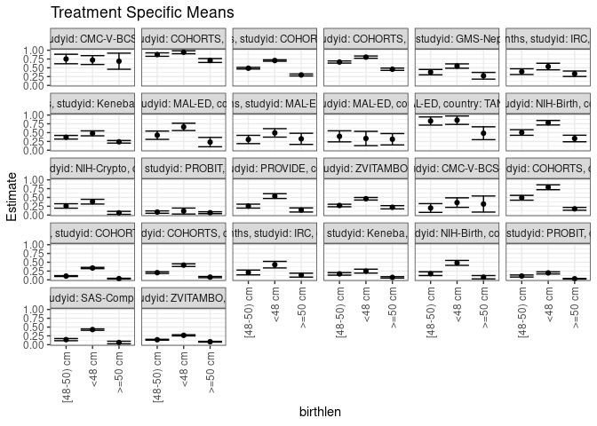

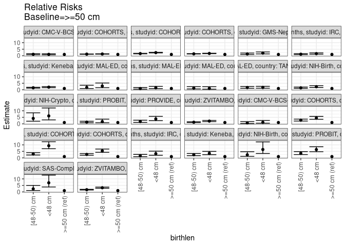

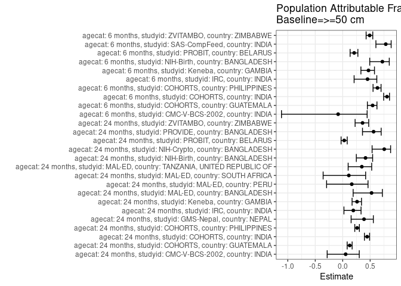

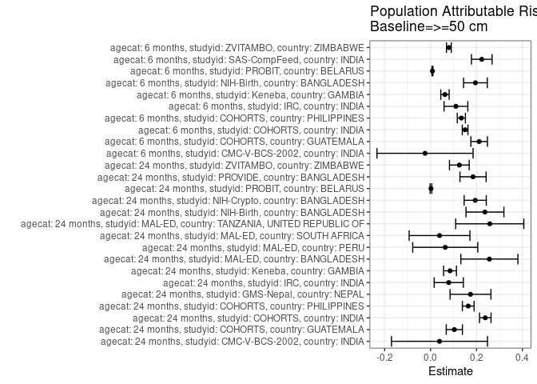

## Results Table

### Parameter: TSM

| agecat | studyid | country | intervention_level | baseline_level | estimate | ci_lower | ci_upper |
| --- | --- | --- | --- | --- | --- | --- | --- |
| 6 months | CMC-V-BCS-2002 | INDIA | >=50 cm | NA | 0.3125000 | 0.0842832 | 0.5407168 |
| 6 months | CMC-V-BCS-2002 | INDIA | <48 cm | NA | 0.3541667 | 0.2182134 | 0.4901199 |
| 6 months | CMC-V-BCS-2002 | INDIA | [48-50) cm | NA | 0.2000000 | 0.0754407 | 0.3245593 |
| 6 months | COHORTS | GUATEMALA | >=50 cm | NA | 0.1766382 | 0.1367129 | 0.2165635 |
| 6 months | COHORTS | GUATEMALA | <48 cm | NA | 0.7894737 | 0.7201375 | 0.8588099 |
| 6 months | COHORTS | GUATEMALA | [48-50) cm | NA | 0.4901961 | 0.4215469 | 0.5588453 |
| 6 months | COHORTS | INDIA | >=50 cm | NA | 0.0360902 | 0.0260655 | 0.0461149 |
| 6 months | COHORTS | INDIA | <48 cm | NA | 0.3367589 | 0.3183419 | 0.3551759 |
| 6 months | COHORTS | INDIA | [48-50) cm | NA | 0.1072527 | 0.0945364 | 0.1199691 |
| 6 months | COHORTS | PHILIPPINES | >=50 cm | NA | 0.0777778 | 0.0610916 | 0.0944639 |
| 6 months | COHORTS | PHILIPPINES | <48 cm | NA | 0.4180207 | 0.3808597 | 0.4551816 |
| 6 months | COHORTS | PHILIPPINES | [48-50) cm | NA | 0.2050290 | 0.1804168 | 0.2296413 |
| 6 months | IRC | INDIA | >=50 cm | NA | 0.1338028 | 0.0777363 | 0.1898694 |
| 6 months | IRC | INDIA | <48 cm | NA | 0.4311927 | 0.3381007 | 0.5242846 |
| 6 months | IRC | INDIA | [48-50) cm | NA | 0.2101449 | 0.1420836 | 0.2782063 |
| 6 months | Keneba | GAMBIA | >=50 cm | NA | 0.0709010 | 0.0515603 | 0.0902417 |
| 6 months | Keneba | GAMBIA | <48 cm | NA | 0.2478632 | 0.1925211 | 0.3032054 |
| 6 months | Keneba | GAMBIA | [48-50) cm | NA | 0.1697248 | 0.1344755 | 0.2049740 |
| 6 months | NIH-Birth | BANGLADESH | >=50 cm | NA | 0.0750000 | 0.0278286 | 0.1221714 |
| 6 months | NIH-Birth | BANGLADESH | <48 cm | NA | 0.4824121 | 0.4129189 | 0.5519053 |
| 6 months | NIH-Birth | BANGLADESH | [48-50) cm | NA | 0.1758794 | 0.1229321 | 0.2288267 |
| 6 months | PROBIT | BELARUS | >=50 cm | NA | 0.0311298 | 0.0212664 | 0.0409932 |
| 6 months | PROBIT | BELARUS | <48 cm | NA | 0.1976744 | 0.1681834 | 0.2271654 |
| 6 months | PROBIT | BELARUS | [48-50) cm | NA | 0.1090487 | 0.0795221 | 0.1385753 |
| 6 months | SAS-CompFeed | INDIA | >=50 cm | NA | 0.0612245 | 0.0254605 | 0.0969884 |
| 6 months | SAS-CompFeed | INDIA | <48 cm | NA | 0.4287729 | 0.4084589 | 0.4490869 |
| 6 months | SAS-CompFeed | INDIA | [48-50) cm | NA | 0.1431981 | 0.1127119 | 0.1736842 |
| 6 months | ZVITAMBO | ZIMBABWE | >=50 cm | NA | 0.0827423 | 0.0720237 | 0.0934609 |
| 6 months | ZVITAMBO | ZIMBABWE | <48 cm | NA | 0.2652985 | 0.2485826 | 0.2820144 |
| 6 months | ZVITAMBO | ZIMBABWE | [48-50) cm | NA | 0.1405180 | 0.1287649 | 0.1522711 |
| 24 months | CMC-V-BCS-2002 | INDIA | >=50 cm | NA | 0.6875000 | 0.4593041 | 0.9156959 |
| 24 months | CMC-V-BCS-2002 | INDIA | <48 cm | NA | 0.7200000 | 0.5949549 | 0.8450451 |
| 24 months | CMC-V-BCS-2002 | INDIA | [48-50) cm | NA | 0.7500000 | 0.6151730 | 0.8848270 |
| 24 months | COHORTS | GUATEMALA | >=50 cm | NA | 0.7072243 | 0.6521810 | 0.7622676 |
| 24 months | COHORTS | GUATEMALA | <48 cm | NA | 0.9416667 | 0.8996954 | 0.9836380 |
| 24 months | COHORTS | GUATEMALA | [48-50) cm | NA | 0.8757062 | 0.8270595 | 0.9243529 |
| 24 months | COHORTS | INDIA | >=50 cm | NA | 0.2970392 | 0.2693575 | 0.3247209 |
| 24 months | COHORTS | INDIA | <48 cm | NA | 0.7068252 | 0.6865351 | 0.7271154 |
| 24 months | COHORTS | INDIA | [48-50) cm | NA | 0.4884637 | 0.4652200 | 0.5117074 |
| 24 months | COHORTS | PHILIPPINES | >=50 cm | NA | 0.4593088 | 0.4266900 | 0.4919276 |
| 24 months | COHORTS | PHILIPPINES | <48 cm | NA | 0.8029801 | 0.7712534 | 0.8347069 |
| 24 months | COHORTS | PHILIPPINES | [48-50) cm | NA | 0.6641870 | 0.6340059 | 0.6943682 |
| 24 months | GMS-Nepal | NEPAL | >=50 cm | NA | 0.2738095 | 0.1783533 | 0.3692658 |
| 24 months | GMS-Nepal | NEPAL | <48 cm | NA | 0.5502008 | 0.4883472 | 0.6120544 |
| 24 months | GMS-Nepal | NEPAL | [48-50) cm | NA | 0.3766234 | 0.3000173 | 0.4532294 |
| 24 months | IRC | INDIA | >=50 cm | NA | 0.3309859 | 0.2534891 | 0.4084827 |
| 24 months | IRC | INDIA | <48 cm | NA | 0.5363636 | 0.4430538 | 0.6296735 |
| 24 months | IRC | INDIA | [48-50) cm | NA | 0.3913043 | 0.3097732 | 0.4728355 |
| 24 months | Keneba | GAMBIA | >=50 cm | NA | 0.2392523 | 0.2030844 | 0.2754203 |
| 24 months | Keneba | GAMBIA | <48 cm | NA | 0.4795918 | 0.4096186 | 0.5495651 |
| 24 months | Keneba | GAMBIA | [48-50) cm | NA | 0.3682635 | 0.3165116 | 0.4200154 |
| 24 months | MAL-ED | BANGLADESH | >=50 cm | NA | 0.2307692 | 0.0981833 | 0.3633551 |
| 24 months | MAL-ED | BANGLADESH | <48 cm | NA | 0.6625000 | 0.5586044 | 0.7663956 |
| 24 months | MAL-ED | BANGLADESH | [48-50) cm | NA | 0.4264706 | 0.3086068 | 0.5443344 |
| 24 months | MAL-ED | PERU | >=50 cm | NA | 0.3235294 | 0.1657859 | 0.4812729 |
| 24 months | MAL-ED | PERU | <48 cm | NA | 0.4925373 | 0.3724509 | 0.6126237 |
| 24 months | MAL-ED | PERU | [48-50) cm | NA | 0.3050847 | 0.1872266 | 0.4229429 |
| 24 months | MAL-ED | SOUTH AFRICA | >=50 cm | NA | 0.3125000 | 0.1510144 | 0.4739856 |
| 24 months | MAL-ED | SOUTH AFRICA | <48 cm | NA | 0.3333333 | 0.1305970 | 0.5360697 |
| 24 months | MAL-ED | SOUTH AFRICA | [48-50) cm | NA | 0.3947368 | 0.2384647 | 0.5510090 |
| 24 months | MAL-ED | TANZANIA, UNITED REPUBLIC OF | >=50 cm | NA | 0.4827586 | 0.3000080 | 0.6655092 |
| 24 months | MAL-ED | TANZANIA, UNITED REPUBLIC OF | <48 cm | NA | 0.8529412 | 0.7333190 | 0.9725634 |
| 24 months | MAL-ED | TANZANIA, UNITED REPUBLIC OF | [48-50) cm | NA | 0.8292683 | 0.7135349 | 0.9450017 |
| 24 months | NIH-Birth | BANGLADESH | >=50 cm | NA | 0.3333333 | 0.2403619 | 0.4263047 |
| 24 months | NIH-Birth | BANGLADESH | <48 cm | NA | 0.7812500 | 0.7171169 | 0.8453831 |
| 24 months | NIH-Birth | BANGLADESH | [48-50) cm | NA | 0.5032258 | 0.4244182 | 0.5820335 |
| 24 months | NIH-Crypto | BANGLADESH | >=50 cm | NA | 0.0625000 | 0.0205249 | 0.1044751 |
| 24 months | NIH-Crypto | BANGLADESH | <48 cm | NA | 0.3800000 | 0.3126646 | 0.4473354 |
| 24 months | NIH-Crypto | BANGLADESH | [48-50) cm | NA | 0.2580645 | 0.1951194 | 0.3210096 |
| 24 months | PROBIT | BELARUS | >=50 cm | NA | 0.0662503 | 0.0397349 | 0.0927658 |
| 24 months | PROBIT | BELARUS | <48 cm | NA | 0.1136364 | 0.0286157 | 0.1986571 |
| 24 months | PROBIT | BELARUS | [48-50) cm | NA | 0.0844156 | 0.0506946 | 0.1181366 |
| 24 months | PROVIDE | BANGLADESH | >=50 cm | NA | 0.1438849 | 0.0854879 | 0.2022819 |
| 24 months | PROVIDE | BANGLADESH | <48 cm | NA | 0.5388350 | 0.4707037 | 0.6069662 |
| 24 months | PROVIDE | BANGLADESH | [48-50) cm | NA | 0.2532189 | 0.1973345 | 0.3091033 |
| 24 months | ZVITAMBO | ZIMBABWE | >=50 cm | NA | 0.2211538 | 0.1750880 | 0.2672197 |
| 24 months | ZVITAMBO | ZIMBABWE | <48 cm | NA | 0.4627286 | 0.4260672 | 0.4993899 |
| 24 months | ZVITAMBO | ZIMBABWE | [48-50) cm | NA | 0.2717949 | 0.2357326 | 0.3078571 |

### Parameter: E(Y)

| agecat | studyid | country | intervention_level | baseline_level | estimate | ci_lower | ci_upper |
| --- | --- | --- | --- | --- | --- | --- | --- |
| 6 months | CMC-V-BCS-2002 | INDIA | NA | NA | 0.2884615 | 0.2009687 | 0.3759544 |
| 6 months | COHORTS | GUATEMALA | NA | NA | 0.3880814 | 0.3516414 | 0.4245214 |
| 6 months | COHORTS | INDIA | NA | NA | 0.1864711 | 0.1767241 | 0.1962180 |
| 6 months | COHORTS | PHILIPPINES | NA | NA | 0.2117734 | 0.1963625 | 0.2271843 |
| 6 months | IRC | INDIA | NA | NA | 0.2442159 | 0.2014677 | 0.2869642 |
| 6 months | Keneba | GAMBIA | NA | NA | 0.1336303 | 0.1154530 | 0.1518076 |
| 6 months | NIH-Birth | BANGLADESH | NA | NA | 0.2702703 | 0.2319893 | 0.3085512 |
| 6 months | PROBIT | BELARUS | NA | NA | 0.0393401 | 0.0293640 | 0.0493162 |
| 6 months | SAS-CompFeed | INDIA | NA | NA | 0.2839879 | 0.2652870 | 0.3026888 |
| 6 months | ZVITAMBO | ZIMBABWE | NA | NA | 0.1624111 | 0.1546051 | 0.1702171 |
| 24 months | CMC-V-BCS-2002 | INDIA | NA | NA | 0.7264151 | 0.6411459 | 0.8116842 |
| 24 months | COHORTS | GUATEMALA | NA | NA | 0.8107143 | 0.7782403 | 0.8431882 |
| 24 months | COHORTS | INDIA | NA | NA | 0.5350988 | 0.5209252 | 0.5492723 |
| 24 months | COHORTS | PHILIPPINES | NA | NA | 0.6232596 | 0.6040367 | 0.6424826 |
| 24 months | GMS-Nepal | NEPAL | NA | NA | 0.4476386 | 0.4034301 | 0.4918471 |
| 24 months | IRC | INDIA | NA | NA | 0.4102564 | 0.3613763 | 0.4591366 |
| 24 months | Keneba | GAMBIA | NA | NA | 0.3239437 | 0.2958244 | 0.3520629 |
| 24 months | MAL-ED | BANGLADESH | NA | NA | 0.4866310 | 0.4148009 | 0.5584611 |
| 24 months | MAL-ED | PERU | NA | NA | 0.3875000 | 0.3117751 | 0.4632249 |
| 24 months | MAL-ED | SOUTH AFRICA | NA | NA | 0.3516484 | 0.2530008 | 0.4502959 |
| 24 months | MAL-ED | TANZANIA, UNITED REPUBLIC OF | NA | NA | 0.7403846 | 0.6557158 | 0.8250534 |
| 24 months | NIH-Birth | BANGLADESH | NA | NA | 0.5700483 | 0.5223021 | 0.6177945 |
| 24 months | NIH-Crypto | BANGLADESH | NA | NA | 0.2568093 | 0.2190047 | 0.2946140 |
| 24 months | PROBIT | BELARUS | NA | NA | 0.0681537 | 0.0420376 | 0.0942697 |
| 24 months | PROVIDE | BANGLADESH | NA | NA | 0.3287197 | 0.2903909 | 0.3670485 |
| 24 months | ZVITAMBO | ZIMBABWE | NA | NA | 0.3463930 | 0.3231291 | 0.3696570 |

### Parameter: RR

| agecat | studyid | country | intervention_level | baseline_level | estimate | ci_lower | ci_upper |
| --- | --- | --- | --- | --- | --- | --- | --- |
| 6 months | CMC-V-BCS-2002 | INDIA | >=50 cm | >=50 cm | 1.0000000 | 1.0000000 | 1.000000 |
| 6 months | CMC-V-BCS-2002 | INDIA | <48 cm | >=50 cm | 1.1333333 | 0.4966487 | 2.586223 |
| 6 months | CMC-V-BCS-2002 | INDIA | [48-50) cm | >=50 cm | 0.6400000 | 0.2451020 | 1.671141 |
| 6 months | COHORTS | GUATEMALA | >=50 cm | >=50 cm | 1.0000000 | 1.0000000 | 1.000000 |
| 6 months | COHORTS | GUATEMALA | <48 cm | >=50 cm | 4.4694397 | 3.5070357 | 5.695948 |
| 6 months | COHORTS | GUATEMALA | [48-50) cm | >=50 cm | 2.7751423 | 2.1271962 | 3.620453 |
| 6 months | COHORTS | INDIA | >=50 cm | >=50 cm | 1.0000000 | 1.0000000 | 1.000000 |
| 6 months | COHORTS | INDIA | <48 cm | >=50 cm | 9.3310277 | 7.0304119 | 12.384492 |
| 6 months | COHORTS | INDIA | [48-50) cm | >=50 cm | 2.9717949 | 2.1971317 | 4.019588 |
| 6 months | COHORTS | PHILIPPINES | >=50 cm | >=50 cm | 1.0000000 | 1.0000000 | 1.000000 |
| 6 months | COHORTS | PHILIPPINES | <48 cm | >=50 cm | 5.3745516 | 4.2607697 | 6.779481 |
| 6 months | COHORTS | PHILIPPINES | [48-50) cm | >=50 cm | 2.6360873 | 2.0615500 | 3.370744 |
| 6 months | IRC | INDIA | >=50 cm | >=50 cm | 1.0000000 | 1.0000000 | 1.000000 |
| 6 months | IRC | INDIA | <48 cm | >=50 cm | 3.2225978 | 2.0113704 | 5.163214 |
| 6 months | IRC | INDIA | [48-50) cm | >=50 cm | 1.5705568 | 0.9248058 | 2.667207 |
| 6 months | Keneba | GAMBIA | >=50 cm | >=50 cm | 1.0000000 | 1.0000000 | 1.000000 |
| 6 months | Keneba | GAMBIA | <48 cm | >=50 cm | 3.4959046 | 2.4573443 | 4.973397 |
| 6 months | Keneba | GAMBIA | [48-50) cm | >=50 cm | 2.3938265 | 1.6990100 | 3.372791 |
| 6 months | NIH-Birth | BANGLADESH | >=50 cm | >=50 cm | 1.0000000 | 1.0000000 | 1.000000 |
| 6 months | NIH-Birth | BANGLADESH | <48 cm | >=50 cm | 6.4321608 | 3.3739117 | 12.262530 |
| 6 months | NIH-Birth | BANGLADESH | [48-50) cm | >=50 cm | 2.3450586 | 1.1676868 | 4.709568 |
| 6 months | PROBIT | BELARUS | >=50 cm | >=50 cm | 1.0000000 | 1.0000000 | 1.000000 |
| 6 months | PROBIT | BELARUS | <48 cm | >=50 cm | 6.3500131 | 4.7201414 | 8.542682 |
| 6 months | PROBIT | BELARUS | [48-50) cm | >=50 cm | 3.5030371 | 2.5465901 | 4.818706 |
| 6 months | SAS-CompFeed | INDIA | >=50 cm | >=50 cm | 1.0000000 | 1.0000000 | 1.000000 |
| 6 months | SAS-CompFeed | INDIA | <48 cm | >=50 cm | 7.0032910 | 3.7970374 | 12.916935 |
| 6 months | SAS-CompFeed | INDIA | [48-50) cm | >=50 cm | 2.3389021 | 1.1000366 | 4.972983 |
| 6 months | ZVITAMBO | ZIMBABWE | >=50 cm | >=50 cm | 1.0000000 | 1.0000000 | 1.000000 |
| 6 months | ZVITAMBO | ZIMBABWE | <48 cm | >=50 cm | 3.2063220 | 2.7761702 | 3.703123 |
| 6 months | ZVITAMBO | ZIMBABWE | [48-50) cm | >=50 cm | 1.6982605 | 1.4555836 | 1.981397 |
| 24 months | CMC-V-BCS-2002 | INDIA | >=50 cm | >=50 cm | 1.0000000 | 1.0000000 | 1.000000 |
| 24 months | CMC-V-BCS-2002 | INDIA | <48 cm | >=50 cm | 1.0472727 | 0.7200585 | 1.523182 |
| 24 months | CMC-V-BCS-2002 | INDIA | [48-50) cm | >=50 cm | 1.0909091 | 0.7479154 | 1.591200 |
| 24 months | COHORTS | GUATEMALA | >=50 cm | >=50 cm | 1.0000000 | 1.0000000 | 1.000000 |
| 24 months | COHORTS | GUATEMALA | <48 cm | >=50 cm | 1.3314964 | 1.2172746 | 1.456436 |
| 24 months | COHORTS | GUATEMALA | [48-50) cm | >=50 cm | 1.2382298 | 1.1253130 | 1.362477 |
| 24 months | COHORTS | INDIA | >=50 cm | >=50 cm | 1.0000000 | 1.0000000 | 1.000000 |
| 24 months | COHORTS | INDIA | <48 cm | >=50 cm | 2.3795692 | 2.1584845 | 2.623299 |
| 24 months | COHORTS | INDIA | [48-50) cm | >=50 cm | 1.6444421 | 1.4810675 | 1.825838 |
| 24 months | COHORTS | PHILIPPINES | >=50 cm | >=50 cm | 1.0000000 | 1.0000000 | 1.000000 |
| 24 months | COHORTS | PHILIPPINES | <48 cm | >=50 cm | 1.7482359 | 1.6117792 | 1.896245 |
| 24 months | COHORTS | PHILIPPINES | [48-50) cm | >=50 cm | 1.4460577 | 1.3291376 | 1.573263 |
| 24 months | GMS-Nepal | NEPAL | >=50 cm | >=50 cm | 1.0000000 | 1.0000000 | 1.000000 |
| 24 months | GMS-Nepal | NEPAL | <48 cm | >=50 cm | 2.0094290 | 1.3931259 | 2.898378 |
| 24 months | GMS-Nepal | NEPAL | [48-50) cm | >=50 cm | 1.3754941 | 0.9186882 | 2.059441 |
| 24 months | IRC | INDIA | >=50 cm | >=50 cm | 1.0000000 | 1.0000000 | 1.000000 |
| 24 months | IRC | INDIA | <48 cm | >=50 cm | 1.6205029 | 1.2105098 | 2.169358 |
| 24 months | IRC | INDIA | [48-50) cm | >=50 cm | 1.1822387 | 0.8641463 | 1.617421 |
| 24 months | Keneba | GAMBIA | >=50 cm | >=50 cm | 1.0000000 | 1.0000000 | 1.000000 |
| 24 months | Keneba | GAMBIA | <48 cm | >=50 cm | 2.0045440 | 1.6246977 | 2.473197 |
| 24 months | Keneba | GAMBIA | [48-50) cm | >=50 cm | 1.5392262 | 1.2521718 | 1.892087 |
| 24 months | MAL-ED | BANGLADESH | >=50 cm | >=50 cm | 1.0000000 | 1.0000000 | 1.000000 |
| 24 months | MAL-ED | BANGLADESH | <48 cm | >=50 cm | 2.8708333 | 1.5825618 | 5.207812 |
| 24 months | MAL-ED | BANGLADESH | [48-50) cm | >=50 cm | 1.8480392 | 0.9768432 | 3.496210 |
| 24 months | MAL-ED | PERU | >=50 cm | >=50 cm | 1.0000000 | 1.0000000 | 1.000000 |
| 24 months | MAL-ED | PERU | <48 cm | >=50 cm | 1.5223881 | 0.8826273 | 2.625871 |
| 24 months | MAL-ED | PERU | [48-50) cm | >=50 cm | 0.9429892 | 0.5062302 | 1.756570 |
| 24 months | MAL-ED | SOUTH AFRICA | >=50 cm | >=50 cm | 1.0000000 | 1.0000000 | 1.000000 |
| 24 months | MAL-ED | SOUTH AFRICA | <48 cm | >=50 cm | 1.0666667 | 0.4801989 | 2.369388 |
| 24 months | MAL-ED | SOUTH AFRICA | [48-50) cm | >=50 cm | 1.2631579 | 0.6587862 | 2.421981 |
| 24 months | MAL-ED | TANZANIA, UNITED REPUBLIC OF | >=50 cm | >=50 cm | 1.0000000 | 1.0000000 | 1.000000 |
| 24 months | MAL-ED | TANZANIA, UNITED REPUBLIC OF | <48 cm | >=50 cm | 1.7668067 | 1.1799532 | 2.645534 |
| 24 months | MAL-ED | TANZANIA, UNITED REPUBLIC OF | [48-50) cm | >=50 cm | 1.7177700 | 1.1474771 | 2.571497 |
| 24 months | NIH-Birth | BANGLADESH | >=50 cm | >=50 cm | 1.0000000 | 1.0000000 | 1.000000 |
| 24 months | NIH-Birth | BANGLADESH | <48 cm | >=50 cm | 2.3437500 | 1.7524388 | 3.134583 |
| 24 months | NIH-Birth | BANGLADESH | [48-50) cm | >=50 cm | 1.5096774 | 1.0963909 | 2.078753 |
| 24 months | NIH-Crypto | BANGLADESH | >=50 cm | >=50 cm | 1.0000000 | 1.0000000 | 1.000000 |
| 24 months | NIH-Crypto | BANGLADESH | <48 cm | >=50 cm | 6.0800000 | 3.0356333 | 12.177492 |
| 24 months | NIH-Crypto | BANGLADESH | [48-50) cm | >=50 cm | 4.1290323 | 2.0208559 | 8.436479 |
| 24 months | PROBIT | BELARUS | >=50 cm | >=50 cm | 1.0000000 | 1.0000000 | 1.000000 |
| 24 months | PROBIT | BELARUS | <48 cm | >=50 cm | 1.7152571 | 0.8163679 | 3.603898 |
| 24 months | PROBIT | BELARUS | [48-50) cm | >=50 cm | 1.2741910 | 0.8209299 | 1.977712 |
| 24 months | PROVIDE | BANGLADESH | >=50 cm | >=50 cm | 1.0000000 | 1.0000000 | 1.000000 |
| 24 months | PROVIDE | BANGLADESH | <48 cm | >=50 cm | 3.7449029 | 2.4480623 | 5.728734 |
| 24 months | PROVIDE | BANGLADESH | [48-50) cm | >=50 cm | 1.7598712 | 1.1087770 | 2.793300 |
| 24 months | ZVITAMBO | ZIMBABWE | >=50 cm | >=50 cm | 1.0000000 | 1.0000000 | 1.000000 |
| 24 months | ZVITAMBO | ZIMBABWE | <48 cm | >=50 cm | 2.0923378 | 1.6743505 | 2.614672 |
| 24 months | ZVITAMBO | ZIMBABWE | [48-50) cm | >=50 cm | 1.2289855 | 0.9600429 | 1.573269 |

### Parameter: PAR

| agecat | studyid | country | intervention_level | baseline_level | estimate | ci_lower | ci_upper |
| --- | --- | --- | --- | --- | --- | --- | --- |
| 6 months | CMC-V-BCS-2002 | INDIA | >=50 cm | NA | -0.0240385 | -0.2331135 | 0.1850366 |
| 6 months | COHORTS | GUATEMALA | >=50 cm | NA | 0.2114432 | 0.1754511 | 0.2474354 |
| 6 months | COHORTS | INDIA | >=50 cm | NA | 0.1503808 | 0.1380551 | 0.1627066 |
| 6 months | COHORTS | PHILIPPINES | >=50 cm | NA | 0.1339956 | 0.1163373 | 0.1516540 |
| 6 months | IRC | INDIA | >=50 cm | NA | 0.1104131 | 0.0586840 | 0.1621422 |
| 6 months | Keneba | GAMBIA | >=50 cm | NA | 0.0627293 | 0.0446055 | 0.0808530 |
| 6 months | NIH-Birth | BANGLADESH | >=50 cm | NA | 0.1952703 | 0.1436988 | 0.2468418 |
| 6 months | PROBIT | BELARUS | >=50 cm | NA | 0.0082103 | 0.0060001 | 0.0104206 |
| 6 months | SAS-CompFeed | INDIA | >=50 cm | NA | 0.2227634 | 0.1778331 | 0.2676937 |
| 6 months | ZVITAMBO | ZIMBABWE | >=50 cm | NA | 0.0796688 | 0.0692847 | 0.0900529 |
| 24 months | CMC-V-BCS-2002 | INDIA | >=50 cm | NA | 0.0389151 | -0.1699483 | 0.2477785 |
| 24 months | COHORTS | GUATEMALA | >=50 cm | NA | 0.1034900 | 0.0682975 | 0.1386824 |
| 24 months | COHORTS | INDIA | >=50 cm | NA | 0.2380596 | 0.2129613 | 0.2631580 |
| 24 months | COHORTS | PHILIPPINES | >=50 cm | NA | 0.1639508 | 0.1384193 | 0.1894823 |
| 24 months | GMS-Nepal | NEPAL | >=50 cm | NA | 0.1738291 | 0.0848181 | 0.2628401 |
| 24 months | IRC | INDIA | >=50 cm | NA | 0.0792705 | 0.0158544 | 0.1426866 |
| 24 months | Keneba | GAMBIA | >=50 cm | NA | 0.0846913 | 0.0566815 | 0.1127011 |
| 24 months | MAL-ED | BANGLADESH | >=50 cm | NA | 0.2558618 | 0.1317402 | 0.3799833 |
| 24 months | MAL-ED | PERU | >=50 cm | NA | 0.0639706 | -0.0775991 | 0.2055403 |
| 24 months | MAL-ED | SOUTH AFRICA | >=50 cm | NA | 0.0391484 | -0.0930207 | 0.1713174 |
| 24 months | MAL-ED | TANZANIA, UNITED REPUBLIC OF | >=50 cm | NA | 0.2576260 | 0.1095014 | 0.4057506 |
| 24 months | NIH-Birth | BANGLADESH | >=50 cm | NA | 0.2367150 | 0.1543169 | 0.3191131 |
| 24 months | NIH-Crypto | BANGLADESH | >=50 cm | NA | 0.1943093 | 0.1462097 | 0.2424089 |
| 24 months | PROBIT | BELARUS | >=50 cm | NA | 0.0019033 | -0.0017964 | 0.0056030 |
| 24 months | PROVIDE | BANGLADESH | >=50 cm | NA | 0.1848348 | 0.1279217 | 0.2417479 |
| 24 months | ZVITAMBO | ZIMBABWE | >=50 cm | NA | 0.1252392 | 0.0823465 | 0.1681319 |

### Parameter: PAF

| agecat | studyid | country | intervention_level | baseline_level | estimate | ci_lower | ci_upper |
| --- | --- | --- | --- | --- | --- | --- | --- |
| 6 months | CMC-V-BCS-2002 | INDIA | >=50 cm | NA | -0.0833333 | -1.1149548 | 0.4450893 |
| 6 months | COHORTS | GUATEMALA | >=50 cm | NA | 0.5448425 | 0.4494865 | 0.6236815 |
| 6 months | COHORTS | INDIA | >=50 cm | NA | 0.8064567 | 0.7462249 | 0.8523929 |
| 6 months | COHORTS | PHILIPPINES | >=50 cm | NA | 0.6327312 | 0.5526235 | 0.6984947 |
| 6 months | IRC | INDIA | >=50 cm | NA | 0.4521127 | 0.2077826 | 0.6210882 |
| 6 months | Keneba | GAMBIA | >=50 cm | NA | 0.4694239 | 0.3317404 | 0.5787401 |
| 6 months | NIH-Birth | BANGLADESH | >=50 cm | NA | 0.7225000 | 0.4923498 | 0.8483084 |
| 6 months | PROBIT | BELARUS | >=50 cm | NA | 0.2087014 | 0.1347564 | 0.2763271 |
| 6 months | SAS-CompFeed | INDIA | >=50 cm | NA | 0.7844116 | 0.6045629 | 0.8824634 |
| 6 months | ZVITAMBO | ZIMBABWE | >=50 cm | NA | 0.4905378 | 0.4264699 | 0.5474488 |
| 24 months | CMC-V-BCS-2002 | INDIA | >=50 cm | NA | 0.0535714 | -0.2827855 | 0.3017328 |
| 24 months | COHORTS | GUATEMALA | >=50 cm | NA | 0.1276528 | 0.0811386 | 0.1718124 |
| 24 months | COHORTS | INDIA | >=50 cm | NA | 0.4448891 | 0.3955006 | 0.4902425 |
| 24 months | COHORTS | PHILIPPINES | >=50 cm | NA | 0.2630538 | 0.2197236 | 0.3039778 |
| 24 months | GMS-Nepal | NEPAL | >=50 cm | NA | 0.3883246 | 0.1533956 | 0.5580618 |
| 24 months | IRC | INDIA | >=50 cm | NA | 0.1932218 | 0.0225898 | 0.3340657 |
| 24 months | Keneba | GAMBIA | >=50 cm | NA | 0.2614384 | 0.1706913 | 0.3422556 |
| 24 months | MAL-ED | BANGLADESH | >=50 cm | NA | 0.5257819 | 0.1900215 | 0.7223595 |
| 24 months | MAL-ED | PERU | >=50 cm | NA | 0.1650854 | -0.2933678 | 0.4610331 |
| 24 months | MAL-ED | SOUTH AFRICA | >=50 cm | NA | 0.1113281 | -0.3564367 | 0.4177851 |
| 24 months | MAL-ED | TANZANIA, UNITED REPUBLIC OF | >=50 cm | NA | 0.3479624 | 0.0994439 | 0.5278994 |
| 24 months | NIH-Birth | BANGLADESH | >=50 cm | NA | 0.4152542 | 0.2483428 | 0.5451017 |
| 24 months | NIH-Crypto | BANGLADESH | >=50 cm | NA | 0.7566288 | 0.5354111 | 0.8725119 |
| 24 months | PROBIT | BELARUS | >=50 cm | NA | 0.0279268 | -0.0294276 | 0.0820858 |
| 24 months | PROVIDE | BANGLADESH | >=50 cm | NA | 0.5622870 | 0.3605805 | 0.7003647 |
| 24 months | ZVITAMBO | ZIMBABWE | >=50 cm | NA | 0.3615523 | 0.2258388 | 0.4734747 |